# 2025 Mid-season VHF Tagging Update

07-15-2025

## Highlights

- Two pre-breeding birds originally tagged in Witless Bay were detected visiting Baccalieu
- All three receivers have been running continuously without any issues
- So far, we have tagged 18 prebreeders on Baccalieu, 12 on Great Island, 6 on Gull Island, and 4 on Middle Lawn
- Additionally, we tagged 3 breeding birds on Gull and 3 on Great to provide controls and points of comparison for analyzing VHF detection patterns
- Of the 14 prebreeders tagged before the last time we downloaded data from all receivers (in other words, for which we have non-night of capture detections), eight have returned to be recorded by at least one receiver. This includes all but two birds tagged in Witless Bay; the Middle Lawn birds have yet to visit any receiver.
- All but one of these returning birds have visited more than one colony
- One bird has retained its tag for 22 days, two have retained their tags for 16 days, and one has retained its tag for 14 days. These are much better retention rates than we had last year.

## Tag Deployment By Site

### Middle Lawn Island

We visited Middle Lawn from 24 June to 28 June. Unfortunately, it was too windy to mist-net for most of the time we were there. We tagged four pre-breeding birds, none of which have been detected by any receivers.

Since we do not have a receiver on Middle Lawn, we would rely on our other stations or on the Motus network to detect these birds. The nearest Motus station to Middle Lawn is on Miquelon, and Motus’ website shows that data from that station has not been uploaded yet this year. I wouldn’t be surprised if we start to see detections from these birds as the Miquelon station and other Atlantic Canada stations start uploading data from their field seasons over the next few months.

### Gull Island

We have had surprisingly little luck catching pre-breeding birds on Gull Island. Our deployment scheme (number of tags deployed per night) is shown below:

| Night-of Date | # tags deployed |
| --- | --- |
| 2025-06-16 | 1 |
| 2025-06-17 | 2 |
| 2025-07-03 | 1 |
| 2025-07-07 | 2 |

Our overall mist-netting capture rate on Gull has been normal, at about 0.28 birds per minute (that average includes periods when the net is closed while we attach tags; the actual rate is higher). However, the percentage of our captures that are pre-breeders is about 4%, much lower than our usual ~10-12%. I suspect that this difference is because we’ve been on Gull on very moonlit nights and we’ve mist-netted in areas that are very dense with petrel burrows. Pre-breeders may be avoiding the moonlight, and breeding birds may be crowding them out in the net. We will visit Gull one or two more times this summer and try to bring our tag count up to 15.

### Great Island

| Night-of Date | # tags deployed |
| --- | --- |
| 2025-06-22 | 6 |
| 2025-07-09 | 6 |

We’ve happened to be on Great Island on slightly darker nights and have mist-netted in areas away from the densest LESP breeding areas. We will visit Great Island one or two more times this summer to bring the number of tags deployed up to 15.

### Baccalieu

Our new station on Baccalieu has been running perfectly and we had fantastic luck mist-netting there on the night of 11 July. Our mist-netting capture rate was 0.5 birds per minute (and we did not close the net at all). About 14% of the birds we captured were pre-breeders, and we deployed 18 tags. We are planning to visit Baccalieu for one more night in the next couple of weeks to bring the number of tags deployed there up to 30.

## Returns and Inter-colony Movements

Here is a summary figure of the return visits and inter-colony movements made by tagged birds. Birds are not included if we have not downloaded receiver data more than a couple of days after they were tagged (since our birds seem to almost universally depart the area for at least two nights after being tagged). This means that all birds tagged on Baccalieu are excluded. Vertical lines represent movements between the Witless Bay colonies within the same night; it’s pretty common for birds for visit both islands in a single night.

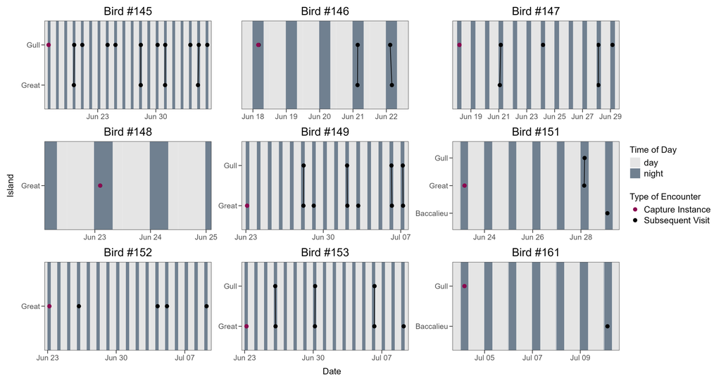

Six out of seven birds that have made return visits to Witless Bay have visited both islands at least once, but several may show a preference for the island where they were tagged. In total, we have detected 33 return visits to the colonies (counting within-night inter-colony movements as single trips). This is much better than our return rate last year, which suggests to me that the smaller, flat bottomed tags are working much better than last year’s tags did. Thanks to the shorter burst intervals on these tags, we are also getting much more information from each visit.

One bird tagged on Great Island on 23 June visited Baccalieu on the night of 28 June, and one bird tagged on Gull Island on 4 July visited Baccalieu on the night of 9 July.

## Example Detection Data

Here is a movement record from bird #149, who was tagged on Great Island on 23 June. When all tag detections are included, the record is quite messy. In general, higher-power transmissions were made closer to the receiver, but VHF data is always noisy.

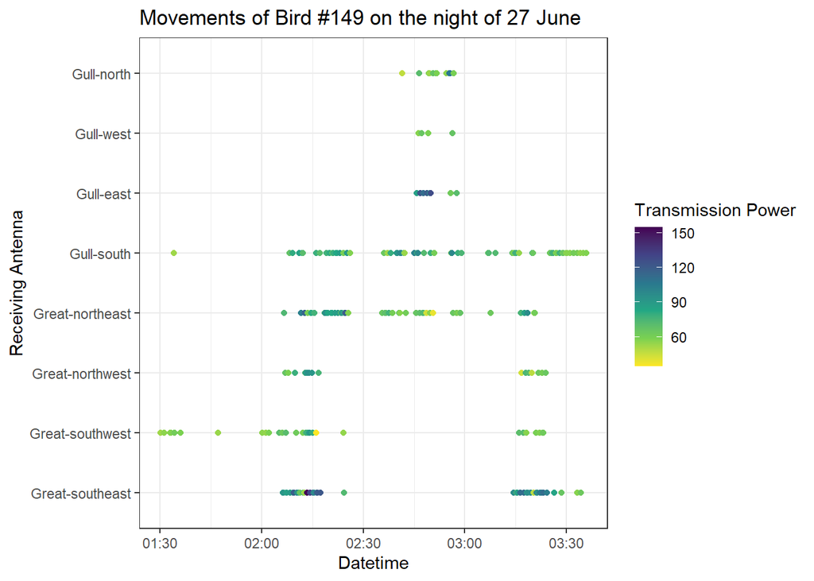

I typically filter the records by taking the strongest record within a two-minute period, which makes the track look like this:

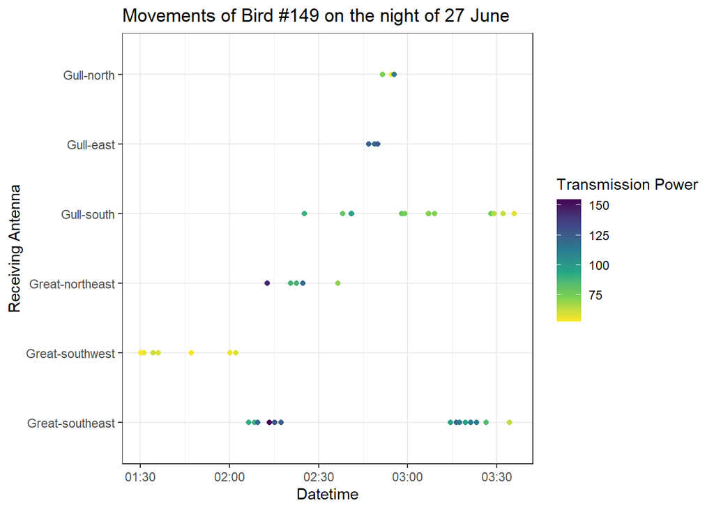

Here are the full movement tracks from both visits made to Baccalieu Island, by birds #151 and #161

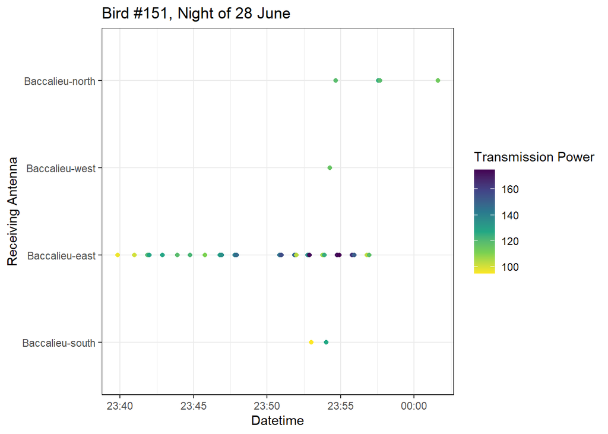

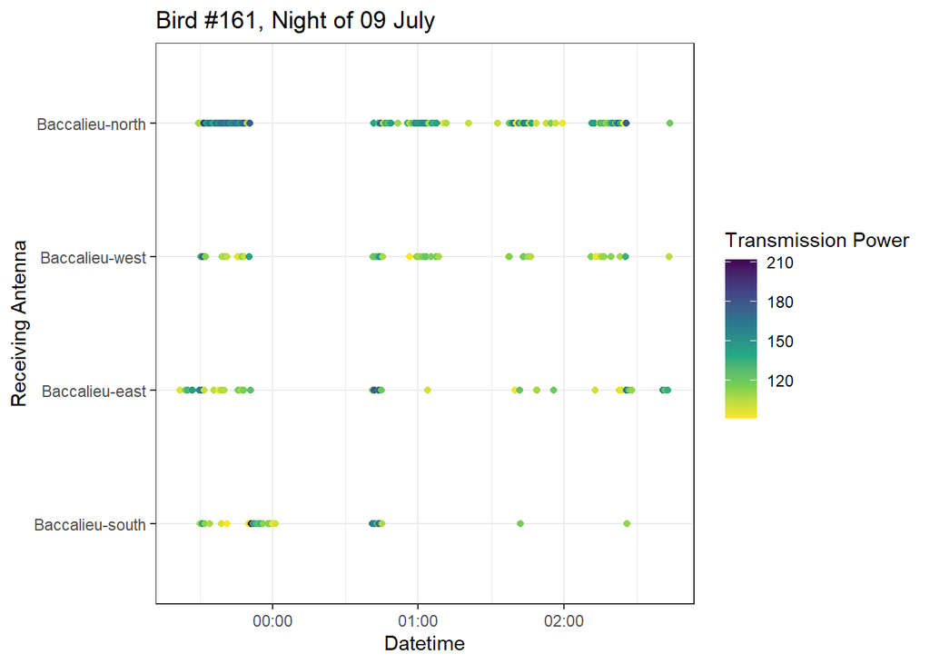

Bird #151 may have only passed by Baccalieu relatively briefly, but its presence on all four antennas and the power of those transmissions suggest it was very close to or on the island. Bird #161 was clearly on the island for an extended visit, and largely spent time north of the receiver station (which is on the southeastern side of the island).

Let me know if you have more questions or would like to see more details!